# GLMM: Introduction

2018-05-15

## Mixed-effects models

- 4.0 Introduction to LMM
- 4.1 Random effects
- 4.2 Solving LM problems using LMM
- 4.3 A showcase of some useful applications
- 4.4 Introduction to GLMM
- 4.5 More complex mixed models

## You will learn in this session

- that GLMM are not very difficult if you already know GLM and LMM

## Non gaussian response

## GLMM

### GLM + LMM = GLMM

\[\begin{array}{lcl} \mu &=& g^{-1}(\eta)\\ \mu &=& g^{-1}(\mathbf{X}\beta + \mathbf{Z}b)\\ \end{array} \]

with (as for GLM):

- \(\text{E}(\text{Y}) = \mu = g^{-1}(\eta)\)
- \(\text{Var}(\text{Y}) = \phi\text{V}(\mu)\)

Note:

- If \(g^{-1}\) is the identity function, \(\phi = \sigma^2\) and \(\text{V}(\mu) = 1\), we have the LMM.
- If \(\mathbf{Z}b = 0\), we have the GLM.
- If \(g^{-1}\) is the identity function, \(\phi = \sigma^2\), \(\text{V}(\mu) = 1\), and \(\mathbf{Z}b = 0\), we have the LM.

## The `LM2GLMM::Flatwork` dataset

```r
Flatwork
```

```
##    individual gender month shopping cleaning other absent
## 1           1      w   nov        4        8     3      0
## 2           2      w   nov       10        5    10      7
## 3           3      w   nov        3        1     2      4
## 4           4      w   nov       15        2     0      0
## 5           5      w   nov       15        9     4      0
## 6           6      m   nov        0        2     8      0
## 7           7      w   nov        5        6     6     10
## 8           8      m   nov        3        4     5     11
## 9           9      m   nov        5        7     6      4
## 10         10      m   nov        6        3     0      7
## 11          1      w   dec        7        6     3      1
## 12          2      w   dec        6        2     3      7
## 13          3      w   dec        5        7     1      5
## 14          4      w   dec       14        5     1      0
```

[output cut: 46 more lines]

## The `LM2GLMM::Flatwork` dataset

```r
str(Flatwork)
```

```
## 'data.frame':    60 obs. of  7 variables:
##  $ individual: int  1 2 3 4 5 6 7 8 9 10 ...
##  $ gender    : Factor w/ 2 levels "m","w": 2 2 2 2 2 1 2 1 1 1 ...
##  $ month     : Factor w/ 6 levels "apr","dec","feb",..: 6 6 6 6 6 6 6 6 6 6 ...
##  $ shopping  : int  4 10 3 15 15 0 5 3 5 6 ...
##  $ cleaning  : int  8 5 1 2 9 2 6 4 7 3 ...
##  $ other     : int  3 10 2 0 4 8 6 5 6 0 ...
##  $ absent    : int  0 7 4 0 0 0 10 11 4 7 ...
```

## GLMM with `lme4`

```r
(mod_glmm_lme4 <- glmer(shopping ~ gender + (1|individual) + (1|month), family = poisson(),
                        data = Flatwork))
```

```
## Generalized linear mixed model fit by maximum likelihood (Laplace Approximation) ['glmerMod']
##  Family: poisson  ( log )
## Formula: shopping ~ gender + (1 | individual) + (1 | month)
##    Data: Flatwork
##       AIC       BIC    logLik  deviance  df.resid
##  421.7239  430.1012 -206.8619  413.7239        56
## Random effects:
##  Groups     Name        Std.Dev.
##  individual (Intercept) 0.2261
##  month      (Intercept) 0.0510
## Number of obs: 60, groups:  individual, 10; month, 6
## Fixed Effects:
## (Intercept)      genderw
##      1.7107       0.2159
```

## GLMM with `spaMM`

```r
(mod_glmm_spaMM <- fitme(shopping ~ gender + (1|individual) + (1|month), family = poisson(),
                        data = Flatwork, method = "ML"))
```

```
## formula: shopping ~ gender + (1 | individual) + (1 | month)
## Estimation of corrPars and lambda by Laplace ML approximation (p_v).
## Estimation of fixed effects by Laplace ML approximation (p_v).
## Estimation of lambda by 'outer' ML, maximizing p_v.
## Family: poisson ( link = log )
##  ------------ Fixed effects (beta) ------------
##             Estimate Cond. SE t-value
## (Intercept)   1.7107   0.1440  11.879
## genderw       0.2159   0.1813   1.191
##  --------------- Random effects ---------------
## Family: gaussian ( link = identity )
##            --- Variance parameters ('lambda'):
## lambda = var(u) for u ~ Gaussian;
##    individual  :  0.05113
##    month  :  0.002602
## # of obs: 60; # of groups: individual, 10; month, 6
##  ------------- Likelihood values  -------------
##                         logLik
## p_v(h) (marginal L): -206.8619
```

## Checking residuals

```
## DHARMa::plotResiduals - low number of unique predictor values, consider setting asFactor = T
## DHARMa::plotResiduals - low number of unique predictor values, consider setting asFactor = T
```

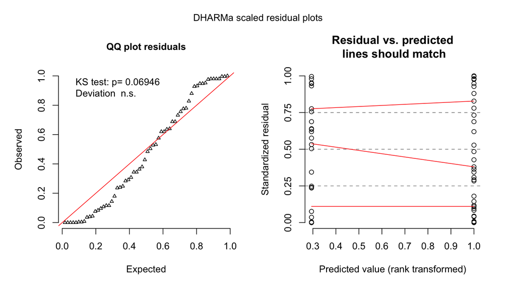

```r
library(DHARMa)
r <- simulateResiduals(mod_glmm_lme4)
plot(r)
```

## Extra 0s?

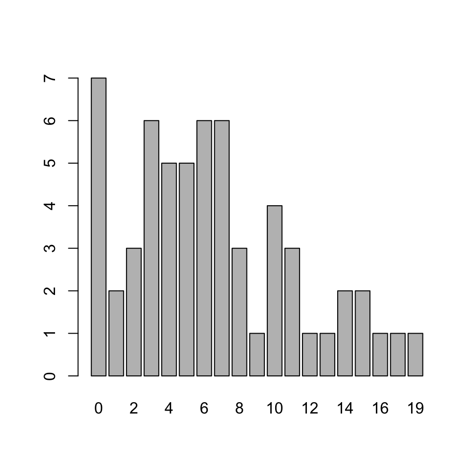

```r
barplot(table(Flatwork$shopping))
```

## Extra 0s?

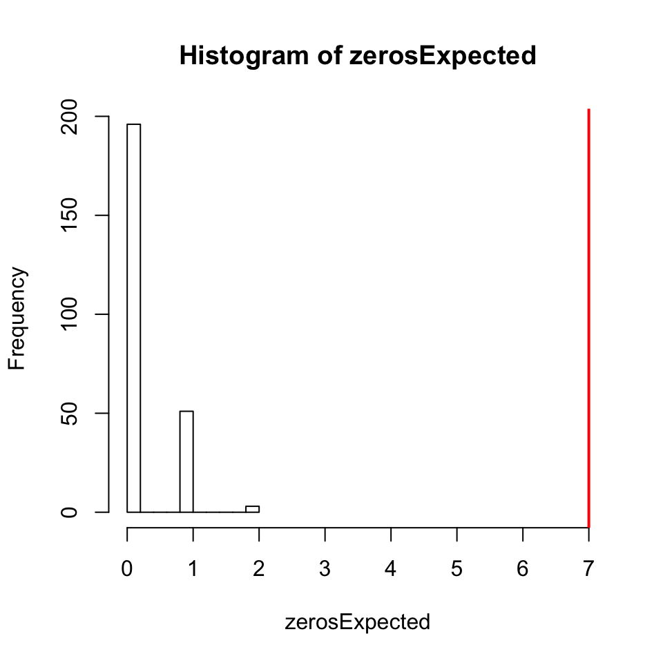

```
##
##  DHARMa zero-inflation test via comparison to expected zeros with simulation under H0 = fitted model
##
## data:  r
## ratioObsExp = 30.702, p-value < 2.2e-16
## alternative hypothesis: more
```

```r
testZeroInflation(r)
```

## Binomial model (to avoid the problem)

```r
Flatwork$shopping_bin <- Flatwork$shopping > 0
(mod_glmm_lme4bin <- glmer(shopping_bin ~ gender + (1|individual) + (1|month), family = binomial(),
                        data = Flatwork))
```

```
## Generalized linear mixed model fit by maximum likelihood (Laplace Approximation) ['glmerMod']
##  Family: binomial  ( logit )
## Formula: shopping_bin ~ gender + (1 | individual) + (1 | month)
##    Data: Flatwork
##      AIC      BIC   logLik deviance df.resid
##  50.2791  58.6565 -21.1396  42.2791       56
## Random effects:
##  Groups     Name        Std.Dev.
##  individual (Intercept) 8.887e-09
##  month      (Intercept) 4.127e-08
## Number of obs: 60, groups:  individual, 10; month, 6
## Fixed Effects:
## (Intercept)      genderw
##      1.6094       0.7885
```

## Checking residuals

```
## DHARMa::plotResiduals - low number of unique predictor values, consider setting asFactor = T
## DHARMa::plotResiduals - low number of unique predictor values, consider setting asFactor = T
```

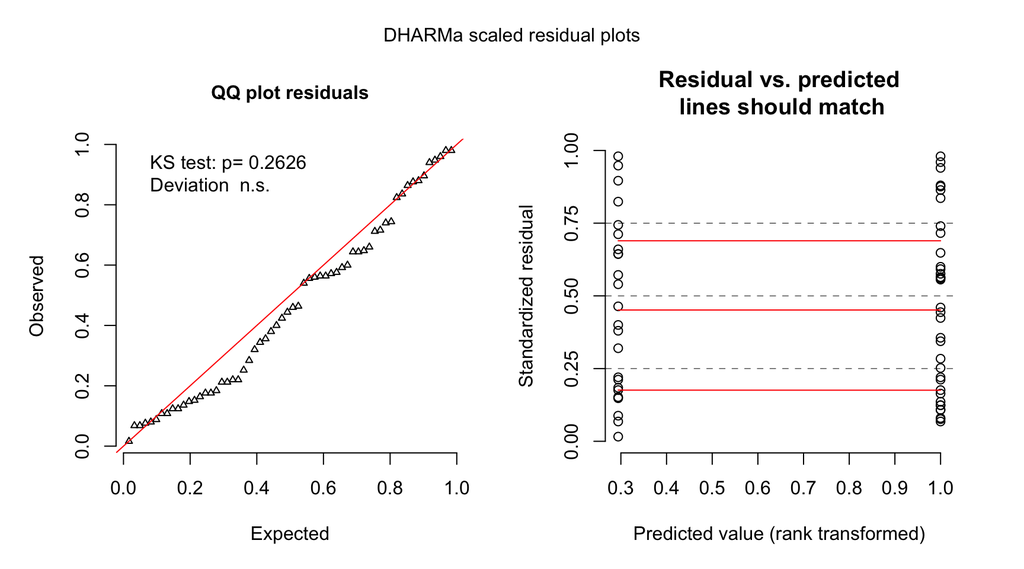

```r
r_bin <- simulateResiduals(mod_glmm_lme4bin)
plot(r_bin)
```

## Testing the gender effect

```r
mod_glmm_lme4bin0 <- glmer(shopping_bin ~ 1 + (1|individual) + (1|month), family = binomial(),
                        data = Flatwork)

anova(mod_glmm_lme4bin, mod_glmm_lme4bin0)
```

```
## Data: Flatwork
## Models:
## mod_glmm_lme4bin0: shopping_bin ~ 1 + (1 | individual) + (1 | month)
## mod_glmm_lme4bin: shopping_bin ~ gender + (1 | individual) + (1 | month)
##                   Df    AIC    BIC  logLik deviance  Chisq Chi Df Pr(>Chisq)
## mod_glmm_lme4bin0  3 49.228 55.511 -21.614   43.228
## mod_glmm_lme4bin   4 50.279 58.657 -21.140   42.279 0.9485      1     0.3301
```

## Same with `spaMM`

```r
mod_glmm_spaMMbin <- fitme(shopping_bin ~ gender + (1|individual) + (1|month), family = binomial(),
                        data = Flatwork)
```

```
## Fits using Laplace approximation may diverge for all-or-none binomial data:
##  check PQL or PQL/L methods in that case.
```

```r
mod_glmm_spaMMbin0 <- fitme(shopping_bin ~ 1 + (1|individual) + (1|month), family = binomial(),
                        data = Flatwork)

anova(mod_glmm_spaMMbin, mod_glmm_spaMMbin0)
```

```
##       chi2_LR df   p_value
## p_v 0.9485333  1 0.3300929
```

## Is there an effect for the non-zeros?

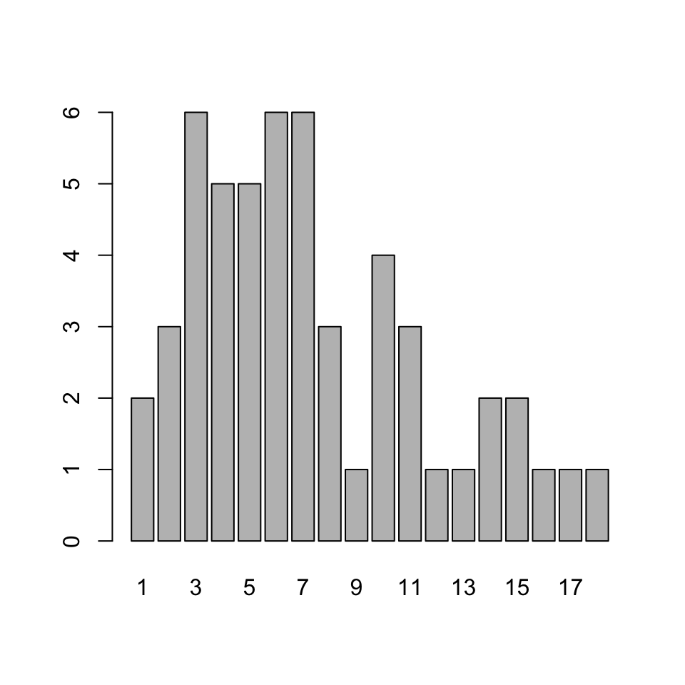

```r
Flatwork_pos <- subset(Flatwork, Flatwork$shopping_bin)
barplot(table(Flatwork_pos$shopping))
```

## Fitting models on truncated distributions

```r
mod_glmm_spaMM_truncP <- fitme(shopping ~ gender + (1|individual) + (1|month), family = Tpoisson(),
                               data = Flatwork_pos)
mod_glmm_spaMM_truncNB <- fitme(shopping ~ gender + (1|individual) + (1|month), family = Tnegbin(),
                                data = Flatwork_pos)
print(AIC(mod_glmm_spaMM_truncP))
```

```
##        marginal AIC:     conditional AIC:      dispersion AIC:        effective df:
##            328.79495            317.96133            324.79495             43.78677
```

```r
print(AIC(mod_glmm_spaMM_truncNB))
```

```
##        marginal AIC:     conditional AIC:      dispersion AIC:        effective df:
##            304.90722            300.90716            300.90722             50.99978
```

Note: this only work with the development version of `spaMM` at the moment…

## A better solution?

```r
library(glmmTMB)
mod_TMB_gender <- glmmTMB(shopping ~ gender + (1|individual) + (1|month), family = poisson(), data = Flatwork,
        ziformula = ~ 1)
mod_TMB_nogender <- glmmTMB(shopping ~ 1 + (1|individual) + (1|month), family = poisson(), data = Flatwork,
        ziformula = ~ 1)
anova(mod_TMB_gender, mod_TMB_nogender)
```

```
## Data: Flatwork
## Models:
## mod_TMB_nogender: shopping ~ 1 + (1 | individual) + (1 | month), zi=~1, disp=~1
## mod_TMB_gender: shopping ~ gender + (1 | individual) + (1 | month), zi=~1, disp=~1
##                  Df    AIC    BIC  logLik deviance  Chisq Chi Df Pr(>Chisq)
## mod_TMB_nogender  4 372.74 381.12 -182.37   364.74
## mod_TMB_gender    5 373.98 384.45 -181.99   363.98 0.7557      1     0.3847
```

`glmmTMB` is extremelly flexible. It allows for both Zero Inflation and Hurdle models (using truncated distributions), as well as modeling the residual variance!

## Checking model assumption

[figure not shown]

```r
plot(simulateResiduals(mod_TMB_gender))
```

Note: the implementation of `DHARMa` for `glmmTMB` is currently in progress!

## Practice

What about gender and cleaning?

## What you need to remember

- that GLMM are not very difficult if you already know GLM and LMM

## Table of contents

## Mixed-effects models

- 4.0 Introduction to LMM
- 4.1 Random effects
- 4.2 Solving LM problems using LMM
- 4.3 A showcase of some useful applications
- 4.4 Introduction to GLMM
- 4.5 More complex mixed models